# Notebook03

### Az apply függvénycsalád - “egysoros for ciklus”"

- lapply: Egy lista minden elemére lefuttatja ugyanazt a függvényt
- sapply: Uaz, mint az lapply, csak próbálja egyszerűbben kiírni az eredményt
- apply: egy többdimenziós objektum (mátrix vagy data frame) soraira ill. oszlopaira futtatunk le valammit
- mapply: több argumentumú függvényt futtat le úgy, hogy az argumentumok több listából jönnek

```r
lapply(1:3, function(n) n*n)
```

```
## [[1]]
## [1] 1
##
## [[2]]
## [1] 4
##
## [[3]]
## [1] 9
```

Oszlopokra alkalmazva

```r
x <- matrix(rnorm(200), 20, 10)
apply(x, 2, function(i) mean(i**2))
```

```
##  [1] 1.4524718 1.0069474 1.0229539 0.7361759 0.6282374 1.2629278 1.2478404
##  [8] 0.9076838 0.8227997 1.0679432
```

### Gépi tanulás R-ben

Sok különböző csomag van, sok algoritmus több csomagban is benne van

kNN az iris adatokon

```r
#install.packages("class")
```

```r
library("class")
```

Normalizáljuk az adatot

```r
# Build your own `normalize()` function
normalize <- function(x) {
num <- x - min(x)
denom <- max(x) - min(x)
return (num/denom)
}

# Normalize the `iris` data
iris_norm <- as.data.frame(lapply(iris[1:4], normalize))

# Summarize `iris_norm`
summary(iris_norm)
```

```
##   Sepal.Length     Sepal.Width      Petal.Length     Petal.Width
##  Min.   :0.0000   Min.   :0.0000   Min.   :0.0000   Min.   :0.00000
##  1st Qu.:0.2222   1st Qu.:0.3333   1st Qu.:0.1017   1st Qu.:0.08333
##  Median :0.4167   Median :0.4167   Median :0.5678   Median :0.50000
##  Mean   :0.4287   Mean   :0.4406   Mean   :0.4675   Mean   :0.45806
##  3rd Qu.:0.5833   3rd Qu.:0.5417   3rd Qu.:0.6949   3rd Qu.:0.70833
##  Max.   :1.0000   Max.   :1.0000   Max.   :1.0000   Max.   :1.00000
```

Tanító és tesztadatok megalkotása

```r
ind <- sample(2, nrow(iris), replace=TRUE, prob=c(0.67, 0.33))
# Compose training set
iris.training <- iris[ind==1, 1:4]

# Inspect training set
head(iris.training)
```

```
##   Sepal.Length Sepal.Width Petal.Length Petal.Width
## 1          5.1         3.5          1.4         0.2
## 3          4.7         3.2          1.3         0.2
## 4          4.6         3.1          1.5         0.2
## 5          5.0         3.6          1.4         0.2
## 6          5.4         3.9          1.7         0.4
## 8          5.0         3.4          1.5         0.2
```

```r
# Compose test set
iris.test <- iris[ind==2, 1:4]

# Inspect test set
head(iris.test)
```

```
##    Sepal.Length Sepal.Width Petal.Length Petal.Width
## 2           4.9         3.0          1.4         0.2
## 7           4.6         3.4          1.4         0.3
## 14          4.3         3.0          1.1         0.1
## 16          5.7         4.4          1.5         0.4
## 17          5.4         3.9          1.3         0.4
## 23          4.6         3.6          1.0         0.2
```

Címkék kialakitása

```r
# Compose `iris` training labels
iris.trainLabels <- iris[ind==1,5]

# Inspect result
print(iris.trainLabels)
```

```
##   [1] setosa     setosa     setosa     setosa     setosa     setosa
##   [7] setosa     setosa     setosa     setosa     setosa     setosa
##  [13] setosa     setosa     setosa     setosa     setosa     setosa
##  [19] setosa     setosa     setosa     setosa     setosa     setosa
##  [25] setosa     setosa     setosa     setosa     setosa     setosa
##  [31] setosa     setosa     setosa     setosa     setosa     versicolor
##  [37] versicolor versicolor versicolor versicolor versicolor versicolor
##  [43] versicolor versicolor versicolor versicolor versicolor versicolor
##  [49] versicolor versicolor versicolor versicolor versicolor versicolor
##  [55] versicolor versicolor versicolor versicolor versicolor versicolor
##  [61] versicolor versicolor versicolor versicolor versicolor versicolor
##  [67] versicolor virginica  virginica  virginica  virginica  virginica
##  [73] virginica  virginica  virginica  virginica  virginica  virginica
##  [79] virginica  virginica  virginica  virginica  virginica  virginica
##  [85] virginica  virginica  virginica  virginica  virginica  virginica
##  [91] virginica  virginica  virginica  virginica  virginica  virginica
##  [97] virginica  virginica  virginica  virginica  virginica  virginica
## Levels: setosa versicolor virginica
```

```r
# Compose `iris` test labels
iris.testLabels <- iris[ind==2, 5]

# Inspect result
print(iris.testLabels)
```

```
##  [1] setosa     setosa     setosa     setosa     setosa     setosa
##  [7] setosa     setosa     setosa     setosa     setosa     setosa
## [13] setosa     setosa     setosa     versicolor versicolor versicolor
## [19] versicolor versicolor versicolor versicolor versicolor versicolor
## [25] versicolor versicolor versicolor versicolor versicolor versicolor
## [31] versicolor versicolor versicolor virginica  virginica  virginica
## [37] virginica  virginica  virginica  virginica  virginica  virginica
## [43] virginica  virginica  virginica  virginica  virginica  virginica
## Levels: setosa versicolor virginica
```

Modell

```r
# Build the model
iris_pred <- knn(train = iris.training, test = iris.test, cl = iris.trainLabels, k=3)

# Inspect `iris_pred`
iris_pred
```

```
##  [1] setosa     setosa     setosa     setosa     setosa     setosa
##  [7] setosa     setosa     setosa     setosa     setosa     setosa
## [13] setosa     setosa     setosa     versicolor versicolor versicolor
## [19] versicolor versicolor virginica  versicolor versicolor versicolor
## [25] versicolor versicolor versicolor versicolor versicolor versicolor
## [31] versicolor versicolor versicolor virginica  virginica  virginica
## [37] virginica  virginica  virginica  virginica  virginica  virginica
## [43] virginica  virginica  virginica  virginica  virginica  virginica
## Levels: setosa versicolor virginica
```

Sok csomag gépi tanulási algoritmusa az alábbi szintakitikát használja

```r
# install.packages("tree")
```

```r
library("tree")
ir.tr <- tree(Species ∼., iris)
summary(ir.tr)
```

```
##
## Classification tree:
## tree(formula = Species ~ ., data = iris)
## Variables actually used in tree construction:
## [1] "Petal.Length" "Petal.Width"  "Sepal.Length"
## Number of terminal nodes:  6
## Residual mean deviance:  0.1253 = 18.05 / 144
## Misclassification error rate: 0.02667 = 4 / 150
```

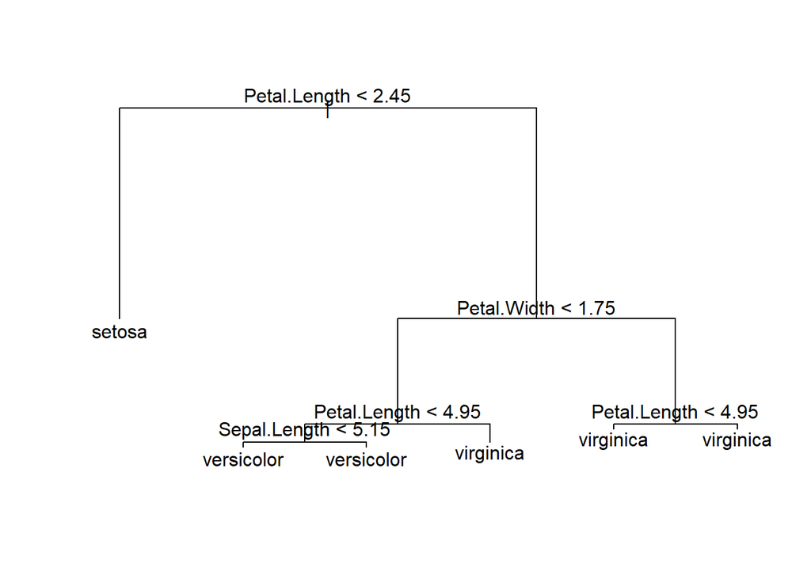

```r
plot(ir.tr)
text(ir.tr)
```